# Linear Mixed Model

Author

Dr Hazlienor Mohd Hatta

Published

April 15, 2024

# Introduction

## Problem

Carbapenems are often considered the last line of defense against multidrug-resistant (MDR) bacterial infections, particularly in hospitalized patients. The increasing reliance on carbapenem therapy has raised concerns about prolonged hospital stays, higher healthcare costs, and the potential for further antimicrobial resistance. Several factors, including patient demographics, disease severity, type of therapy, and hospital-specific practices, may influence the length of hospital stay among patients receiving carbapenems.

## Research Question

What are the factors that influence the length of hospital stay of patients receiving carbapenem therapy for multidrug-resistant infections in northern Peninsular Malaysia?

## Objective

1. To examine the factors influencing length of hospital stay among patients receiving carbapenem therapy for multidrug-resistant infections in northern Peninsular Malaysia.

# Description of Data set

The dataset comprises **651 patient** records from **34 hospitals** in the northern region of Peninsular Malaysia, focusing on patients receiving carbapenem therapy for multidrug-resistant infections. It includes both individual-level and hospital-level factors.

Key outcome variables include:

**Patient-Level (Inter-Individual) Variables**

| Variable Name | Description | Data Type | Possible Values / Range |
| --- | --- | --- | --- |
| patient_id | Unique identifier for each patient | Integer | 1 to 651 |
| hospital_id | Identifies the hospital where the patient was treated | Integer | 1 to 34 (corresponding to different hospitals) |
| age | Patient’s age | Integer | 18 to 89 years |
| eGFR | Estimated Glomerular Filtration Rate, indicating kidney function | Continuous | 15 to 120 mL/min/1.73m² |
| SOFA | Sequential Organ Failure Assessment score, measures severity of illness | Integer | 0 to 15 (higher values indicate greater severity) |
| therapy | Type of antibiotic therapy received | Categorical | *Monotherapy* or *Combination Therapy* |

| Variable Name | Description | Data Type | Possible Values / Range |
| --- | --- | --- | --- |
| day | Number of days the patient was hospitalized | Continuous | 1 to 20 days (shorter stays indicate better outcomes) |
| status | Survival status at discharge | Binary | 1 = Alive, 0 = Dead |

# Workflow

1. Prepare environment
2. Load data
3. Data exploration and wrangling
4. Descriptive analysis
5. Univariate analysis
6. Multilevel analysis
   - estimate
   - inference
   - prediction
7. Data presentation and interpretation

# Analysis

## Prepare Environment

**Install required packages**

(remove the # when you want to run this code)

```r
#install.packages(setdiff(c("readxl", "tidyverse", "lme4", "lmerTest", "gtsummary", "sjPlot", "lattice", "DHARMa", "broom.helpers", "glmmTMB"),  rownames(installed.packages())), dependencies = TRUE)
```

**Load required packages**

```r
library(readxl) # read xlsx data set
library(tidyverse) # data manipulation, visualization, and wrangling
library(lme4) # fitting linear mixed-effects models
library(lmerTest) # providing p-values for fixed effects
library(gtsummary) # summarizing model results
library(broom.mixed) #tidy, summarize mixed models
library(broom.helpers)
library(sjPlot) # visualizing and summarizing mixed-effects model results
library(lattice) # visualizing mixed-effects model results
library(DHARMa) # checking residual diagnostics for hierarchical regression models
library(glmmTMB)
```

## Load Data

```r
carba <-read_xlsx("carbapenem.xlsx")
```

## Data Exploration & Wrangling

Examine the structure of the data

```r
str(carba)
```

```
tibble [651 × 10] (S3: tbl_df/tbl/data.frame)
 $ patient_id           : num [1:651] 1 2 3 4 5 6 7 8 9 10 ...
 $ hospital_id          : num [1:651] 1 7 28 4 20 23 27 5 25 7 ...
 $ age                  : num [1:651] 40 30 67 32 30 39 34 54 56 56 ...
 $ eGFR                 : num [1:651] 97.2 43.1 83.9 82.9 80.2 ...
 $ SOFA                 : num [1:651] 9 9 8 1 6 4 12 6 9 9 ...
 $ therapy              : chr [1:651] "Combination" "Monotherapy" "Monotherapy" "Combination" ...
 $ day                  : num [1:651] 8 8 4 6 6 4 7 5 6 6 ...
 $ status               : num [1:651] 1 1 1 1 1 1 1 1 1 1 ...
 $ hospital_type        : chr [1:651] "General Specialist" "ID Specialist" "General Specialist" "General Specialist" ...
 $ local_resistance_rate: num [1:651] 39.8 56.4 21.8 52.3 21.4 ...
```

**Variables:**

**data**: carba

**independent variable**: age, eGFR, SOFA, therapy, hospital_type, local_resistance_rate

**outcome variable**: day, status

Convert all character variables into factors, and label categorical variables such as `status` (0 = Dead, 1 = Alive) appropriately to ensure that the data is correctly recognized as categorical for modeling and visualization

```r
carba <- carba %>%
  mutate(
    across(where(is.character), as.factor),  # Convert character variables to factors
    status = factor(status, levels = c(0, 1), labels = c("Dead", "Alive"))  # Convert numeric status to labeled factor
  )
```

## Descriptive analysis

**Overall distribution**

Summarize the distribution of the data

```r
summary(carba)
```

```
   patient_id     hospital_id         age             eGFR
 Min.   :  1.0   Min.   : 1.00   Min.   :18.00   Min.   : 30.03
 1st Qu.:163.5   1st Qu.: 9.00   1st Qu.:35.00   1st Qu.: 52.33
 Median :326.0   Median :18.00   Median :48.00   Median : 74.94
 Mean   :326.0   Mean   :17.94   Mean   :47.11   Mean   : 74.28
 3rd Qu.:488.5   3rd Qu.:26.00   3rd Qu.:57.00   3rd Qu.: 94.95
 Max.   :651.0   Max.   :34.00   Max.   :89.00   Max.   :119.59
      SOFA               therapy         day           status
 Min.   : 1.000   Combination:314   Min.   : 1.000   Dead : 65
 1st Qu.: 4.000   Monotherapy:337   1st Qu.: 5.000   Alive:586
 Median : 7.000                     Median : 6.000
 Mean   : 7.512                     Mean   : 6.502
 3rd Qu.:11.000                     3rd Qu.: 8.000
 Max.   :14.000                     Max.   :20.000
            hospital_type local_resistance_rate
 General Specialist:228   Min.   :21.38
 ID Specialist     :262   1st Qu.:27.84
 No Specialist     :161   Median :35.55
                          Mean   :38.44
                          3rd Qu.:51.01
                          Max.   :58.78
```

Tabulate the characteristic of the patient

```r
tbl_summary(carba)
```

| **Characteristic** | **N = 651**<sup>1</sup> |
| --- | --- |
| patient_id | 326 (163, 489) |
| hospital_id | 18 (9, 26) |
| age | 48 (35, 57) |
| eGFR | 75 (52, 95) |
| SOFA | 7.0 (4.0, 11.0) |
| therapy |  |
| Combination | 314 (48%) |
| Monotherapy | 337 (52%) |
| day | 6.00 (5.00, 8.00) |
| status |  |
| Dead | 65 (10.0%) |
| Alive | 586 (90%) |
| hospital_type |  |
| General Specialist | 228 (35%) |
| ID Specialist | 262 (40%) |
| No Specialist | 161 (25%) |
| local_resistance_rate | 36 (28, 51) |

<sup>1</sup> Median (Q1, Q3); n (%)

provide mean, sd and set decimal point

```r
carba %>%
  select(-patient_id, -hospital_id) %>% # remove unwanted variable
  tbl_summary(
    statistic = list(all_continuous() ~ "{mean} ({sd})",  # Mean (SD) for numeric variables
                     all_categorical() ~ "{n} ({p}%)"),  # Count (percentage) for categorical variables
    digits = list(
      all_continuous() ~ 1,  # 1 decimal place for numeric variables
      all_categorical() ~ 1  # 1 decimal place for percentages
    ),
    label = list(
      day ~ "Length of Stay (days)",
      age ~ "Age (years)",
      local_resistance_rate ~ "Resistance Rate",
      hospital_type ~ "Hospital Type"
    )
  )
```

| **Characteristic** | **N = 651**<sup>1</sup> |
| --- | --- |
| Age (years) | 47.1 (14.8) |
| eGFR | 74.3 (25.0) |
| SOFA | 7.5 (4.0) |
| therapy |  |
| Combination | 314.0 (48.2%) |
| Monotherapy | 337.0 (51.8%) |
| Length of Stay (days) | 6.5 (2.6) |
| status |  |
| Dead | 65.0 (10.0%) |
| Alive | 586.0 (90.0%) |
| Hospital Type |  |
| General Specialist | 228.0 (35.0%) |
| ID Specialist | 262.0 (40.2%) |
| No Specialist | 161.0 (24.7%) |
| Resistance Rate | 38.4 (12.0) |

<sup>1</sup> Mean (SD); n (%)

**Distribution of outcome (length of stay)**

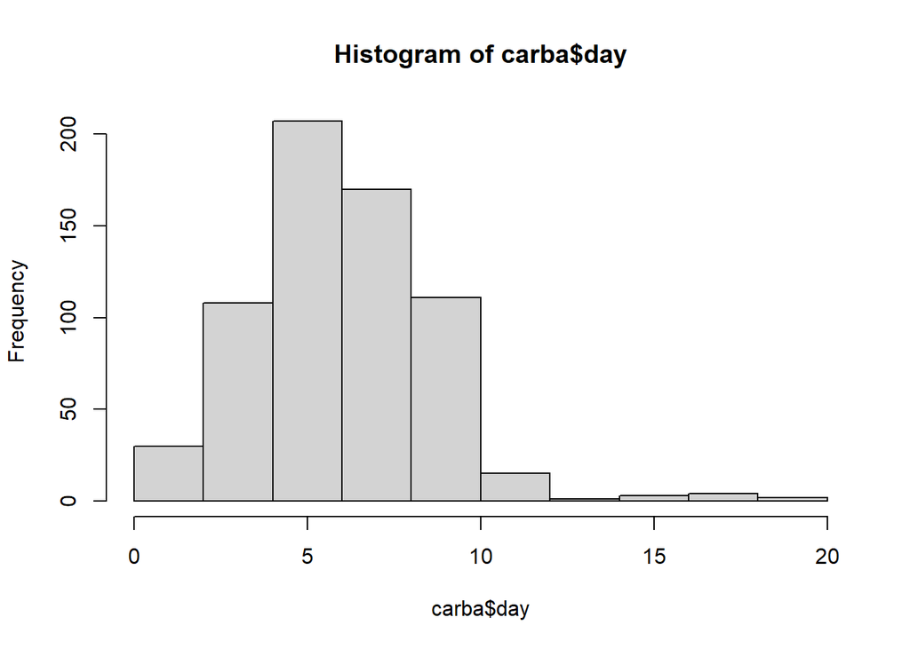

```r
hist(carba$day)
```

**Distribution by hospital**

average length of stay by hospital

```r
carba %>% group_by(hospital_id) %>%
  summarise(
    count = n(),
    mean = mean(day, na.rm=TRUE),
    sd = sd(day, na.rm=TRUE)
  )
```

```
# A tibble: 34 × 4
   hospital_id count  mean    sd
         <dbl> <int> <dbl> <dbl>
 1           1    24  5.54  2.15
 2           2    19  5.79  2.82
 3           3    20 11.0   3.97
 4           4    16  7.38  1.71
 5           5    23  6.52  1.73
 6           6    19  4.68  2.54
 7           7    13  6.38  2.26
 8           8    21  8.29  2.22
 9           9    16  6.69  1.92
10          10    16  9.12  2.99
# ℹ 24 more rows
```

Visualize the length of stay (day), by hospitals (hospital_id)

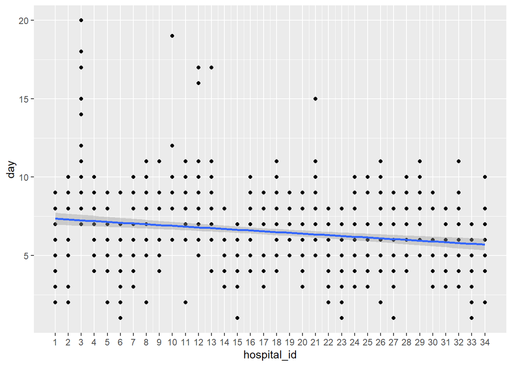

```r
carba %>%
  ggplot(aes(x = hospital_id, y = day)) +
  geom_point() +
  geom_smooth(method = lm) +
  scale_x_continuous(breaks = unique(carba$hospital_id), labels = unique(carba$hospital_id))
```

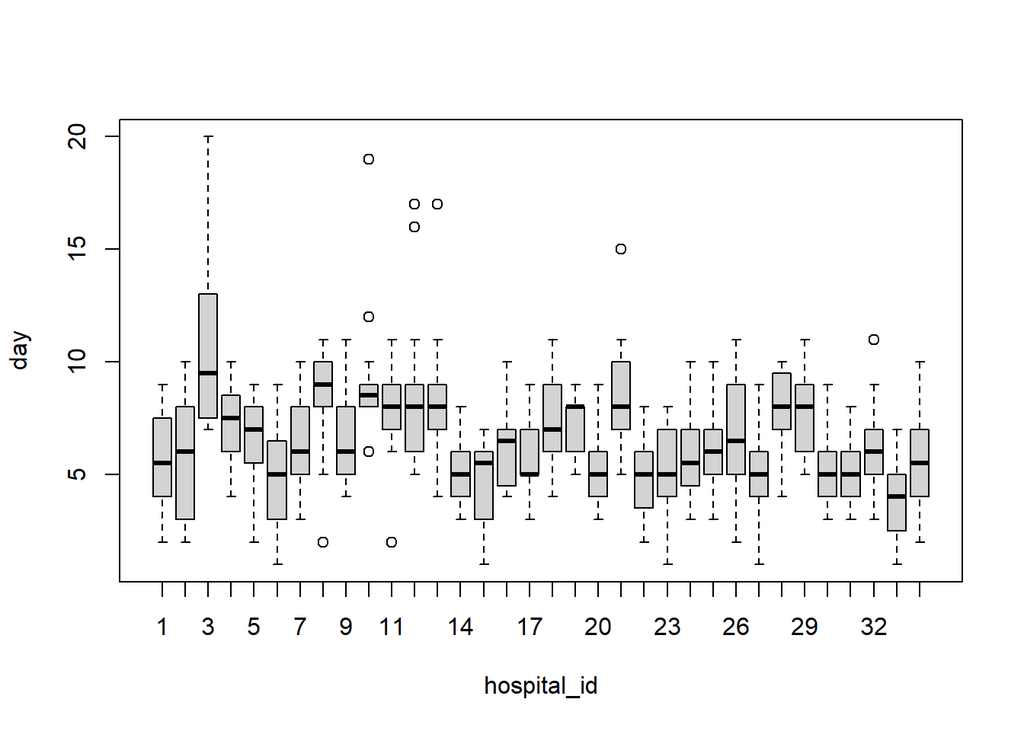

```r
boxplot(day ~ hospital_id, data = carba)
```

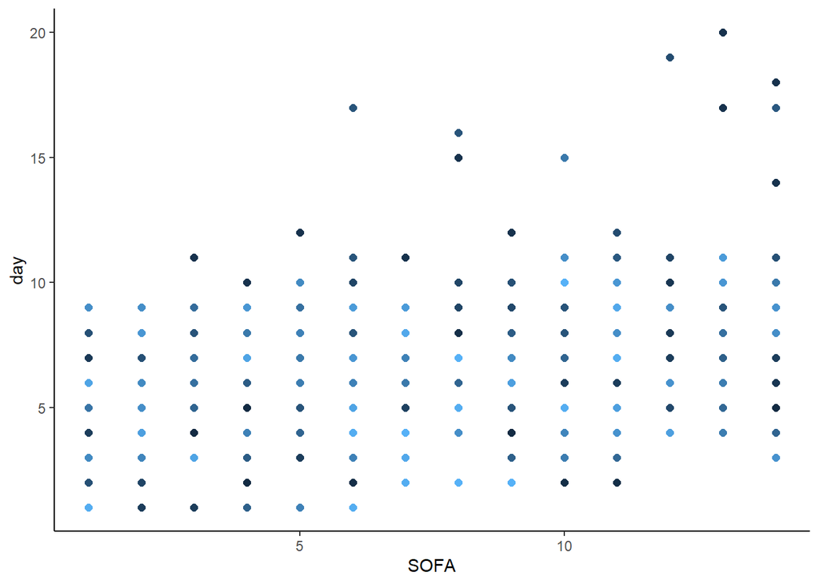

```r
(colour_plot <- ggplot(carba, aes(x = SOFA, y = day, colour = hospital_id)) +
  geom_point(size = 2) +
  theme_classic() +
  theme(legend.position = "none"))
```

Visualize the length of stay (day), by hospitals (hospital_id) and patient factor

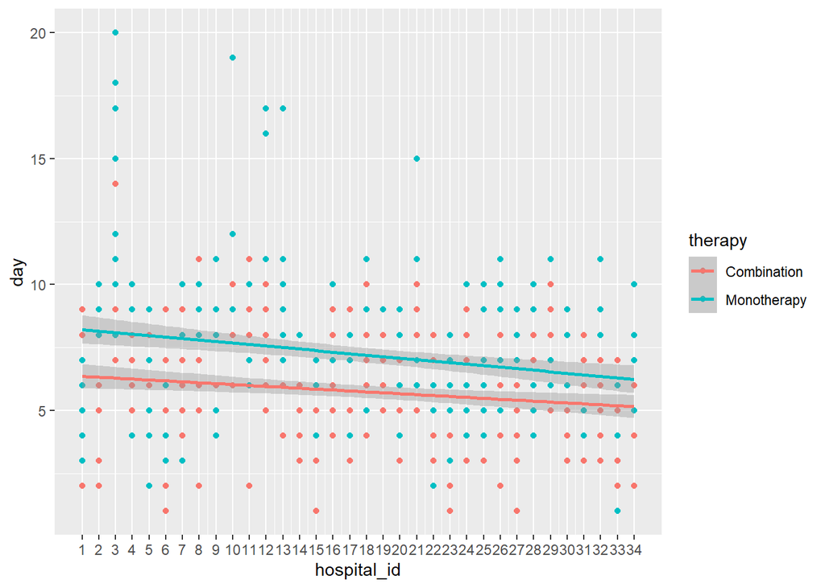

```r
carba %>%
  ggplot(aes(x = hospital_id, y = day, col = therapy, group = therapy)) +
  geom_point() +
  geom_smooth(method = lm) +
  scale_x_continuous(breaks = unique(carba$hospital_id), labels = unique(carba$hospital_id))
```

Visualize the length of stay (day), by hospitals (hospital_id) and hospital factor

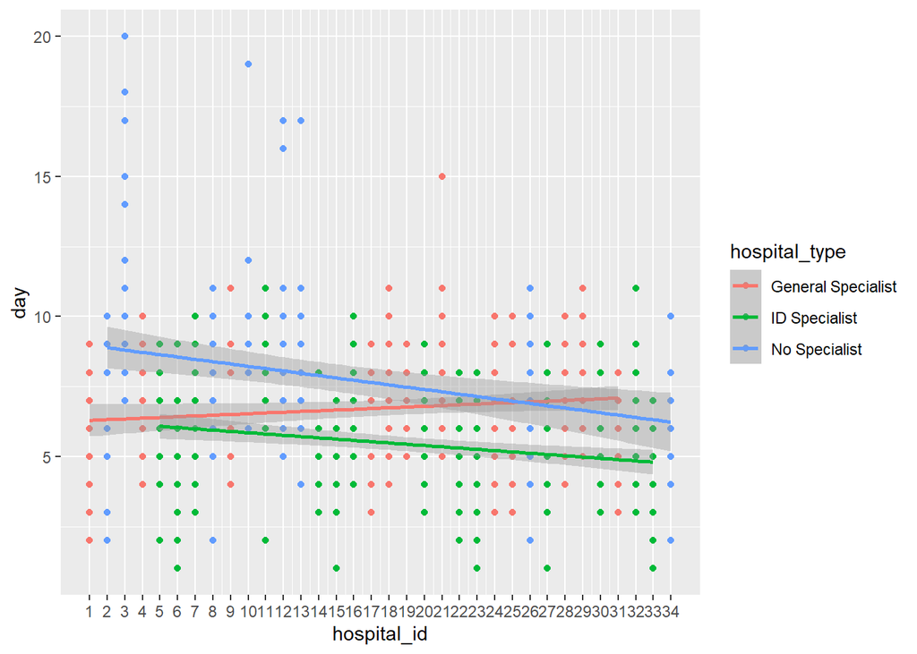

```r
carba %>%
  ggplot(aes(x = hospital_id, y = day, col = hospital_type, group = hospital_type)) +
  geom_point() +
  geom_smooth(method = lm) +
  scale_x_continuous(breaks = unique(carba$hospital_id), labels = unique(carba$hospital_id))
```

## Unilevel Analysis

Lets do simple and multiple linear regression

### **Simple linear regression**

univariable analysis for all predictors available on the dataset.

```r
carba %>%
  tbl_uvregression(
    method = lm,  # Linear regression
    y = day,      # Outcome variable
    include = -c(patient_id, hospital_id, status) # Exclude unwanted variables
  )
```

| **Characteristic** | **N** | **Beta** | **95% CI** | **p-value** |
| --- | --- | --- | --- | --- |
| age | 651 | 0.05 | 0.03, 0.06 | <0.001 |
| eGFR | 651 | -0.03 | -0.04, -0.02 | <0.001 |
| SOFA | 651 | 0.26 | 0.21, 0.31 | <0.001 |
| therapy | 651 |  |  |  |
| Combination |  | — | — |  |
| Monotherapy |  | 1.5 | 1.1, 1.9 | <0.001 |
| hospital_type | 651 |  |  |  |
| General Specialist |  | — | — |  |
| ID Specialist |  | -1.3 | -1.8, -0.91 | <0.001 |
| No Specialist |  | 1.1 | 0.62, 1.6 | <0.001 |
| local_resistance_rate | 651 | -0.01 | -0.03, 0.01 | 0.2 |

Abbreviation: CI = Confidence Interval

### **Multiple linear regression**

lets select a few variable to be included in the model (age, SOFA, therapy)

```r
mlr <- lm(day ~ age + SOFA + therapy, data = carba)
summary(mlr)
```

```
Call:
lm(formula = day ~ age + SOFA + therapy, data = carba)

Residuals:
    Min      1Q  Median      3Q     Max
-5.9573 -1.5266 -0.0426  1.3884 10.1029

Coefficients:
                   Estimate Std. Error t value Pr(>|t|)
(Intercept)        2.390933   0.327571   7.299 8.53e-13 ***
age                0.034777   0.006033   5.764 1.27e-08 ***
SOFA               0.242667   0.022359  10.853  < 2e-16 ***
therapyMonotherapy 1.256276   0.178051   7.056 4.43e-12 ***
---
Signif. codes:  0 '***' 0.001 '**' 0.01 '*' 0.05 '.' 0.1 ' ' 1

Residual standard error: 2.243 on 647 degrees of freedom
Multiple R-squared:  0.2671,    Adjusted R-squared:  0.2637
F-statistic: 78.61 on 3 and 647 DF,  p-value: < 2.2e-16
```

summarize the model in table

```r
tbl_regression(mlr)
```

| **Characteristic** | **Beta** | **95% CI** | **p-value** |
| --- | --- | --- | --- |
| age | 0.03 | 0.02, 0.05 | <0.001 |
| SOFA | 0.24 | 0.20, 0.29 | <0.001 |
| therapy |  |  |  |
| Combination | — | — |  |
| Monotherapy | 1.3 | 0.91, 1.6 | <0.001 |

Abbreviation: CI = Confidence Interval

For each 1-year increase in age, the expected increase in the length of hospital stay is 0.03 days (95% CI: 0.02, 0.05; p-value <0.001), when adjusted for SOFA score and therapy type.

Each 1-point increase in the SOFA score is associated with an increase of 0.24 days in the outcome (95% CI: 0.20, 0.29; p-value <0.001), when adjusted for age and therapy type.

Patients who received monotherapy had an increase of 1.3 days in the outcome compared to those on combination therapy (95% CI: 0.91, 1.6, <0.001), when adjusted for age and SOFA score.

**Age has a meaningful association with the length of hospital stay, higher severity of illness (SOFA score) is linked to a longer hospital stay, monotherapy may lead to longer hospital stays compared to combination therapy.**

## Multilevel Analysis

### Motivation

- Patients receiving treatment at the same hospital are more likely to have similar outcomes due to **shared hospital-specific factors** such as treatment protocols, resource availability, and healthcare staff expertise.
- Standard linear regression assumes **independence of observations** which is violated when data is **clustered** within hospital.
- Standard regression assumes **homoscedasticity** (constant variance), but in reality, hospitals may exhibit **different levels of variability** in patient outcomes.

### **Single predictor**

A **random intercept effect** means that we assume each group (e.g., hospital) has its own baseline level (intercept), but the effect of the predictors (slopes) remains the same across groups.

#### **Constant only model**

The model estimates the **overall average length of stay (LOS)** across all hospitals. No predictor variables are included, meaning it assumes LOS is the same for all patients except for hospital-level differences.

```r
cmodel <- lmer(day ~ 1 + (1 | hospital_id), data = carba, REML = FALSE)
summary(cmodel)
```

```
Linear mixed model fit by maximum likelihood . t-tests use Satterthwaite's
  method [lmerModLmerTest]
Formula: day ~ 1 + (1 | hospital_id)
   Data: carba

      AIC       BIC    logLik -2*log(L)  df.resid
   2938.6    2952.0   -1466.3    2932.6       648

Scaled residuals:
    Min      1Q  Median      3Q     Max
-2.8160 -0.6275 -0.0706  0.6141  4.6972

Random effects:
 Groups      Name        Variance Std.Dev.
 hospital_id (Intercept) 2.082    1.443
 Residual                4.714    2.171
Number of obs: 651, groups:  hospital_id, 34

Fixed effects:
            Estimate Std. Error      df t value Pr(>|t|)
(Intercept)   6.5196     0.2622 34.1459   24.86   <2e-16 ***
---
Signif. codes:  0 '***' 0.001 '**' 0.01 '*' 0.05 '.' 0.1 ' ' 1
```

The model suggests that the **average hospital stay is 6.5 days**. There is **moderate variation between hospitals (SD = 1.4 days)**, meaning some hospitals have longer or shorter LOS due to hospital differences.

The **residual variation (SD = 2.2 days)** shows that LOS varies significantly within hospitals due to patient-level factors.

#### **Random intercept effect**

We would like to examine the fixed effect of SOFA score on the LOS while also **controlling for the random effect of hospital (intercept)**, assuming that **hospitals** have different baseline effects on **length of stay (days)** but the effect of SOFA score remains the same across hospitals.

```r
model_SOFA_ri <- lmer(day ~ SOFA + (1 | hospital_id), data = carba, REML = FALSE)
summary(model_SOFA_ri)
```

```
Linear mixed model fit by maximum likelihood . t-tests use Satterthwaite's
  method [lmerModLmerTest]
Formula: day ~ SOFA + (1 | hospital_id)
   Data: carba

      AIC       BIC    logLik -2*log(L)  df.resid
   2801.7    2819.6   -1396.9    2793.7       647

Scaled residuals:
    Min      1Q  Median      3Q     Max
-2.5172 -0.6458  0.0210  0.5789  4.7101

Random effects:
 Groups      Name        Variance Std.Dev.
 hospital_id (Intercept) 1.967    1.402
 Residual                3.779    1.944
Number of obs: 651, groups:  hospital_id, 34

Fixed effects:
             Estimate Std. Error        df t value Pr(>|t|)
(Intercept)   4.66972    0.29316  61.06613   15.93   <2e-16 ***
SOFA          0.24681    0.01981 624.19707   12.46   <2e-16 ***
---
Signif. codes:  0 '***' 0.001 '**' 0.01 '*' 0.05 '.' 0.1 ' ' 1

Correlation of Fixed Effects:
     (Intr)
SOFA -0.507
```

summarize model

```r
tab_model(model_SOFA_ri)
```

|  | day |  |  |
| --- | --- | --- | --- |
| Predictors | Estimates | CI | p |
| (Intercept) | 4.67 | 4.09 – 5.25 | **<0.001** |
| SOFA | 0.25 | 0.21 – 0.29 | **<0.001** |
| Random Effects |  |  |  |
| σ<sup>2</sup> | 3.78 |  |  |
| τ<sub>00</sub> <sub>hospital_id</sub> | 1.97 |  |  |
| ICC | 0.34 |  |  |
| N <sub>hospital_id</sub> | 34 |  |  |
| Observations | 651 |  |  |
| Marginal R<sup>2</sup> / Conditional R<sup>2</sup> | 0.142 / 0.436 |  |  |

**Interpretation**

**Random Effects (Hospital-Level Variability):**

- **Hospital Intercept Variance = 1.97**→ The average difference in LOS **between hospitals.**
  - The **variance in LOS due to differences between hospitals** is **1.97 days²**. Hospitals **differ, on average, by about** **√1.97 = 1.4 days** in their baseline LOS.
- **Residual Variance = 3.78** → The remaining unexplained variation **within hospitals**.The **variance in LOS within hospitals (patient-level differences)** is **3.78 days²**. After accounting for **hospital differences and patient’s SOFA score**, the LOS still varies **within each hospital** by **√3.78 = 1.9 days** on average.
- The **Intraclass Correlation Coefficient (ICC)** tells us how much of the total variance in **length of stay (LOS)** is explained by **hospital-level** differences. It is calculated as:

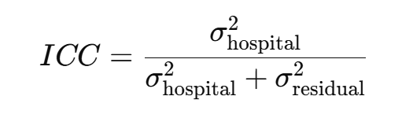

```r
1.967/(1.967+3.779)
```

```
[1] 0.3423251
```

- About **34.2% of the total variability** in **length of stay (LOS)** is due to differences **between hospitals**.
- The remaining **65.8% of the variability** is due to **individual patient SOFA score differences within hospitals** and other unexplained factors not included in the model.
- Hospital-level factors have effect on LOS, however major variation is explained by patient-specific factors rather than hospital-level differences.

**Moderate Negative Correlation between predictor and intercept (-0.507)**

#### Random slope effect

A **random slope effect** means that the relationship between a **predictor** variable (e.g., SOFA) and the **outcome** variable (e.g., length of stay (LOS)) **varies across groups** (e.g., hospitals).

**Random intercept with single random slope model**

Instead of assuming a single fixed effect for all hospitals, this model allows each hospital to have its **own unique slope** for SOFA score. Each hospital can have **a different baseline LOS** **and** a **different effect of SOFA** on LOS, for example, due to:

- different thresholds for treating patients with high SOFA scores. E.g., one hospital may discharge patients earlier if their SOFA score improves, while another might keep patients for longer periods.
- Different hospitals may treat different types of patients. E.g., a hospital that primarily treats critical care patients might see a stronger relationship between SOFA and LOS, as severe cases typically require longer stays.
- Some hospitals may have better resources. A well-resourced hospital might manage patients with higher SOFA scores more efficiently.

We would want to estimate the **fixed effect of risk factors (SOFA score)** on the LOS while also **controlling for the random effect of SOFA score (slope) and hospital (intercept)**

```r
model_SOFA_rs <- lmer(day ~ SOFA + (1 + SOFA| hospital_id), data = carba, REML = FALSE)
```

```
boundary (singular) fit: see help('isSingular')
```

```r
summary(model_SOFA_rs)
```

```
Linear mixed model fit by maximum likelihood . t-tests use Satterthwaite's
  method [lmerModLmerTest]
Formula: day ~ SOFA + (1 + SOFA | hospital_id)
   Data: carba

      AIC       BIC    logLik -2*log(L)  df.resid
   2805.3    2832.2   -1396.7    2793.3       645

Scaled residuals:
    Min      1Q  Median      3Q     Max
-2.4760 -0.6502  0.0331  0.5938  4.7368

Random effects:
 Groups      Name        Variance  Std.Dev. Corr
 hospital_id (Intercept) 1.6846842 1.29795
             SOFA        0.0001808 0.01345  1.00
 Residual                3.7773021 1.94353
Number of obs: 651, groups:  hospital_id, 34

Fixed effects:
             Estimate Std. Error        df t value Pr(>|t|)
(Intercept)   4.66694    0.27854  35.20510   16.75   <2e-16 ***
SOFA          0.24698    0.01996 389.85352   12.38   <2e-16 ***
---
Signif. codes:  0 '***' 0.001 '**' 0.01 '*' 0.05 '.' 0.1 ' ' 1

Correlation of Fixed Effects:
     (Intr)
SOFA -0.436
optimizer (nloptwrap) convergence code: 0 (OK)
boundary (singular) fit: see help('isSingular')
```

summarize the model

```r
tab_model(model_SOFA_rs)
```

|  | day |  |  |
| --- | --- | --- | --- |
| Predictors | Estimates | CI | p |
| (Intercept) | 4.67 | 4.12 – 5.21 | **<0.001** |
| SOFA | 0.25 | 0.21 – 0.29 | **<0.001** |
| Random Effects |  |  |  |
| σ<sup>2</sup> | 3.78 |  |  |
| τ<sub>00</sub> <sub>hospital_id</sub> | 1.68 |  |  |
| τ<sub>11</sub> <sub>hospital_id.SOFA</sub> | 0.00 |  |  |
| ρ<sub>01</sub> <sub>hospital_id</sub> | 1.00 |  |  |
| N <sub>hospital_id</sub> | 34 |  |  |
| Observations | 651 |  |  |
| Marginal R<sup>2</sup> / Conditional R<sup>2</sup> | 0.202 / NA |  |  |

**Interpretation:**

**Fixed effect:**

- Each 1-unit increase in SOFA is associated with a 0.25-day (95% CI: 0.21, 0.29; p <0.001) increase in LOS when adjusted for random effect of hospital and random effect of SOFA score.

#### Model comparison

hence, which model is better? lets compare the model using anova test

```r
anova(cmodel, model_SOFA_ri, model_SOFA_rs )
```

```
Data: carba
Models:
cmodel: day ~ 1 + (1 | hospital_id)
model_SOFA_ri: day ~ SOFA + (1 | hospital_id)
model_SOFA_rs: day ~ SOFA + (1 + SOFA | hospital_id)
              npar    AIC    BIC  logLik -2*log(L)    Chisq Df Pr(>Chisq)
cmodel           3 2938.6 2952.0 -1466.3    2932.6
model_SOFA_ri    4 2801.7 2819.6 -1396.9    2793.7 138.8450  1     <2e-16 ***
model_SOFA_rs    6 2805.3 2832.2 -1396.7    2793.3   0.4057  2     0.8164
---
Signif. codes:  0 '***' 0.001 '**' 0.01 '*' 0.05 '.' 0.1 ' ' 1
```

**Lower AIC/BIC is better** → The **model_SOFA_ri** (random intercept only) has the lowest AIC (2801.7), indicating a **better fit** than the other two. **Adding a random slope (model_SOFA_rs) does NOT improve the model** (*p = 0.8164*), indicating that SOFA score affects LOS similarly across hospitals.

**conclusion?**

✅ **SOFA score has significant effect on LOS.**  
✅ **Hospitals differ in baseline LOS, but SOFA score effects barely vary between hospitals.**

### Multiple predictors

Lets examine how **patient characteristics** (age, severity based on SOFA score) and **treatment** **factor** (type pf therapy) influence LOS while accounting for **variability between hospitals.**

- **Age**: Older patients may have longer LOS due to **weakened immune response, comorbidities, or slower recovery rates**.
- **SOFA Score**: The **Sequential Organ Failure Assessment (SOFA)** score reflects **disease severity**. Higher scores suggest **worse clinical conditions**, which may prolong LOS.
- **Therapy Type**: Patients receiving **monotherapy vs. combination therapy** may experience different LOS due to **treatment effectiveness or resistance patterns.**

#### Random intercept model

```r
model_ast_ri <- lmer(day ~ age + SOFA + therapy + (1 | hospital_id), data = carba, REML = FALSE)
summary(model_ast_ri)
```

```
Linear mixed model fit by maximum likelihood . t-tests use Satterthwaite's
  method [lmerModLmerTest]
Formula: day ~ age + SOFA + therapy + (1 | hospital_id)
   Data: carba

      AIC       BIC    logLik -2*log(L)  df.resid
   2729.5    2756.3   -1358.7    2717.5       645

Scaled residuals:
    Min      1Q  Median      3Q     Max
-2.5254 -0.6721 -0.0022  0.6199  4.4823

Random effects:
 Groups      Name        Variance Std.Dev.
 hospital_id (Intercept) 1.782    1.335
 Residual                3.358    1.833
Number of obs: 651, groups:  hospital_id, 34

Fixed effects:
                    Estimate Std. Error        df t value Pr(>|t|)
(Intercept)        3.655e+00  3.636e-01 1.567e+02  10.054   <2e-16 ***
age                9.333e-03  5.244e-03 6.314e+02   1.780   0.0756 .
SOFA               2.380e-01  1.876e-02 6.233e+02  12.683   <2e-16 ***
therapyMonotherapy 1.250e+00  1.475e-01 6.199e+02   8.477   <2e-16 ***
---
Signif. codes:  0 '***' 0.001 '**' 0.01 '*' 0.05 '.' 0.1 ' ' 1

Correlation of Fixed Effects:
            (Intr) age    SOFA
age         -0.614
SOFA        -0.323 -0.087
thrpyMnthrp -0.104 -0.141 -0.023
```

```r
tab_model(model_ast_ri)
```

|  | day |  |  |
| --- | --- | --- | --- |
| Predictors | Estimates | CI | p |
| (Intercept) | 3.66 | 2.94 – 4.37 | **<0.001** |
| age | 0.01 | -0.00 – 0.02 | 0.076 |
| SOFA | 0.24 | 0.20 – 0.27 | **<0.001** |
| therapy [Monotherapy] | 1.25 | 0.96 – 1.54 | **<0.001** |
| Random Effects |  |  |  |
| σ<sup>2</sup> | 3.36 |  |  |
| τ<sub>00</sub> <sub>hospital_id</sub> | 1.78 |  |  |
| ICC | 0.35 |  |  |
| N <sub>hospital_id</sub> | 34 |  |  |
| Observations | 651 |  |  |
| Marginal R<sup>2</sup> / Conditional R<sup>2</sup> | 0.213 / 0.486 |  |  |

**Key interpretation:**

- Age: No significant association between age and LOS.
- SOFA Score : Higher disease severity significantly leads to a longer LOS.
- Therapy Type : Patients on monotherapy tend to have a longer LOS compared to those on combination therapy.
- Random effect (hospital variance = 1.78, SD=1.34 days): There is variation in LOS between hospitals.

#### Random intercept model with single random slope

Lets asssess how **age, SOFA** score, and **therapy** type influence the LOS among patients receiving carbapenem for MDR infections while allowing **therapy effects to vary by hospital**.

```r
model_ast_rs <- lmer(day ~ age + SOFA + therapy + (1 + therapy| hospital_id), data = carba, REML = FALSE)
summary(model_ast_rs)
```

```
Linear mixed model fit by maximum likelihood . t-tests use Satterthwaite's
  method [lmerModLmerTest]
Formula: day ~ age + SOFA + therapy + (1 + therapy | hospital_id)
   Data: carba

      AIC       BIC    logLik -2*log(L)  df.resid
   2708.2    2744.0   -1346.1    2692.2       643

Scaled residuals:
    Min      1Q  Median      3Q     Max
-2.5490 -0.6428 -0.0308  0.6126  4.6377

Random effects:
 Groups      Name               Variance Std.Dev. Corr
 hospital_id (Intercept)        1.429    1.195
             therapyMonotherapy 1.079    1.039    0.07
 Residual                       3.079    1.755
Number of obs: 651, groups:  hospital_id, 34

Fixed effects:
                    Estimate Std. Error        df t value Pr(>|t|)
(Intercept)        3.856e+00  3.428e-01 1.555e+02  11.250  < 2e-16 ***
age                4.372e-03  5.162e-03 6.204e+02   0.847    0.397
SOFA               2.397e-01  1.820e-02 6.108e+02  13.169  < 2e-16 ***
therapyMonotherapy 1.279e+00  2.286e-01 3.513e+01   5.594 2.62e-06 ***
---
Signif. codes:  0 '***' 0.001 '**' 0.01 '*' 0.05 '.' 0.1 ' ' 1

Correlation of Fixed Effects:
            (Intr) age    SOFA
age         -0.636
SOFA        -0.325 -0.096
thrpyMnthrp -0.028 -0.093 -0.016
```

**Key interpretation**

- Age is not significantly affecting LOS.
- Higher SOFA score significantly increase LOS.
- Monotherapy is associated with a significantly longer LOS than combination therapy.
- Variance in hospital intercepts (1.429) indicates that baseline LOS differs across hospitals.
- Variance in therapy slopes (1.079) suggests that the impact of therapy on LOS varies by hospital.

#### Model comparison

which model is better?

```r
anova(model_ast_ri, model_ast_rs)
```

```
Data: carba
Models:
model_ast_ri: day ~ age + SOFA + therapy + (1 | hospital_id)
model_ast_rs: day ~ age + SOFA + therapy + (1 + therapy | hospital_id)
             npar    AIC    BIC  logLik -2*log(L)  Chisq Df Pr(>Chisq)
model_ast_ri    6 2729.5 2756.3 -1358.7    2717.5
model_ast_rs    8 2708.2 2744.0 -1346.1    2692.2 25.272  2  3.253e-06 ***
---
Signif. codes:  0 '***' 0.001 '**' 0.01 '*' 0.05 '.' 0.1 ' ' 1
```

**model_ast_rs** (random intercept + random slope for therapy) provides a **significantly better fit** to the data than **model_ast_ri** (random intercept only). The improvement is statistically significant (**p < 0.001**), meaning that including the random slope for **therapy** accounts for more variability in **hospital stay duration** across hospitals. The residual variance also reduce upon addition of random slope, thi suggests that allowing the slope of variable to vary between clusters captures more of the data’s structure.

Lets calculate the ICC for the **model_ast_rs:**

```r
1.429/(1.429+3.079)
```

```
[1] 0.316992
```

About **31.7%** of the variability in the **LOS** (day) is attributable to differences between hospitals (hospital-level clustering).

You can also use the **performance** package if you want to calculate the **R²**

```r
#install.packages("performance")
```

```r
library(performance)
r2_nakagawa(model_ast_rs)
```

```
# R2 for Mixed Models

  Conditional R2: 0.529
     Marginal R2: 0.211
```

- **Marginal R²**: proportion of variance explained by **fixed effects**
- **Conditional R²**: proportion of variance explained by **fixed + random effects**

**52.9%** of total variance explained by the **whole model**

#### **Preliminary Final Model**

We select the model with lower AIC/BIC and improved log-likelihood as the preliminary final model: **model_ast_rs.**

lets re-run the final model using REML

```r
final_model <- lmer(day ~ age + SOFA + therapy + (1 + therapy| hospital_id), data = carba)
summary(final_model)
```

```
Linear mixed model fit by REML. t-tests use Satterthwaite's method [
lmerModLmerTest]
Formula: day ~ age + SOFA + therapy + (1 + therapy | hospital_id)
   Data: carba

REML criterion at convergence: 2709.3

Scaled residuals:
    Min      1Q  Median      3Q     Max
-2.5527 -0.6424 -0.0308  0.6109  4.6292

Random effects:
 Groups      Name               Variance Std.Dev. Corr
 hospital_id (Intercept)        1.483    1.218
             therapyMonotherapy 1.131    1.064    0.06
 Residual                       3.089    1.758
Number of obs: 651, groups:  hospital_id, 34

Fixed effects:
                    Estimate Std. Error        df t value Pr(>|t|)
(Intercept)        3.861e+00  3.455e-01 1.476e+02  11.173  < 2e-16 ***
age                4.277e-03  5.174e-03 6.173e+02   0.827    0.409
SOFA               2.397e-01  1.824e-02 6.080e+02  13.144  < 2e-16 ***
therapyMonotherapy 1.279e+00  2.321e-01 3.407e+01   5.509 3.72e-06 ***
---
Signif. codes:  0 '***' 0.001 '**' 0.01 '*' 0.05 '.' 0.1 ' ' 1

Correlation of Fixed Effects:
            (Intr) age    SOFA
age         -0.632
SOFA        -0.323 -0.097
thrpyMnthrp -0.030 -0.091 -0.016
```

#### Model Checking

Lets check the model fitness to evaluate if the mixed-effects model is appropriately modeling both **fixed effects** (predictors) and **random effects** (group-level variations).

We can use the package - **DHARMa**: residual diagnostics for hierarchical (multi-level/mixed) regression models

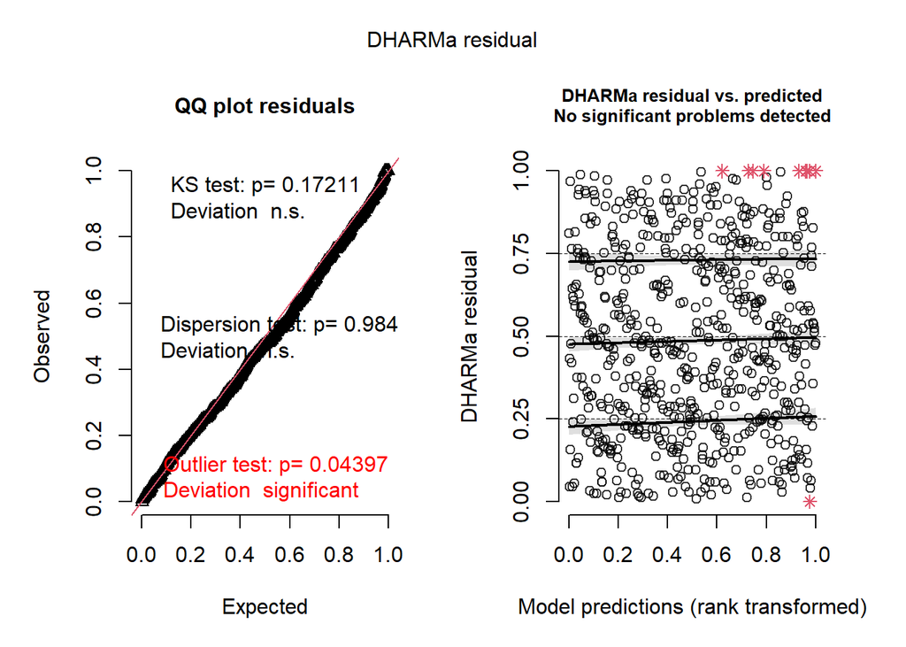

```r
library(DHARMa)
sim_res <- simulateResiduals(final_model)
plot(sim_res)
```

**Kolmogorov–Smirnov test:** check normality of residuals, p-value < 0.05 suggests model misspecification

**Dispersion test:** check whether model is overdispersed or underdispersed , whether the residual variance matches the model’s expected variance. p-value < 0.05 suggests significant dispersion

**Outlier test:** Slight deviations from the 45° red line at the tails — supports the test result of mild non-uniformity/outliers

**Residual vs predicted plot:**

- Homoscedasticity (constant variance) & independence - The residuals are **scattered evenly** across the predicted values — no funnel shape or **pattern/trend**.
- **Red stars (*)** mark **potential outliers**. These are simulated residuals that significantly deviate from expected bounds.
- DHARMa rank-transforms residuals, so 0 to 1 scale is **expected** and helps identify unusual behavior.

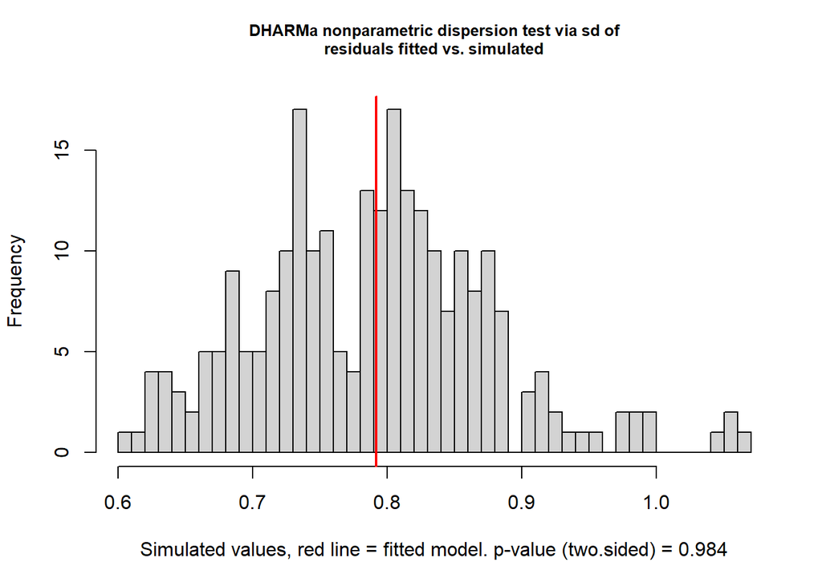

```
    DHARMa nonparametric dispersion test via sd of residuals fitted vs.
    simulated

data:  simulationOutput
dispersion = 1.0033, p-value = 0.984
alternative hypothesis: two.sided
```

```r
testDispersion(final_model)
```

or you can use **sjplot** package to plot the diagnostic

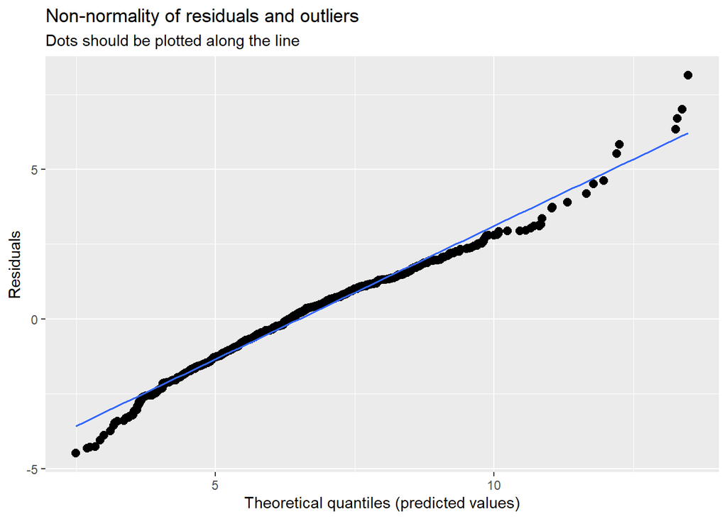

```
[[2]]
[[2]]$hospital_id
```

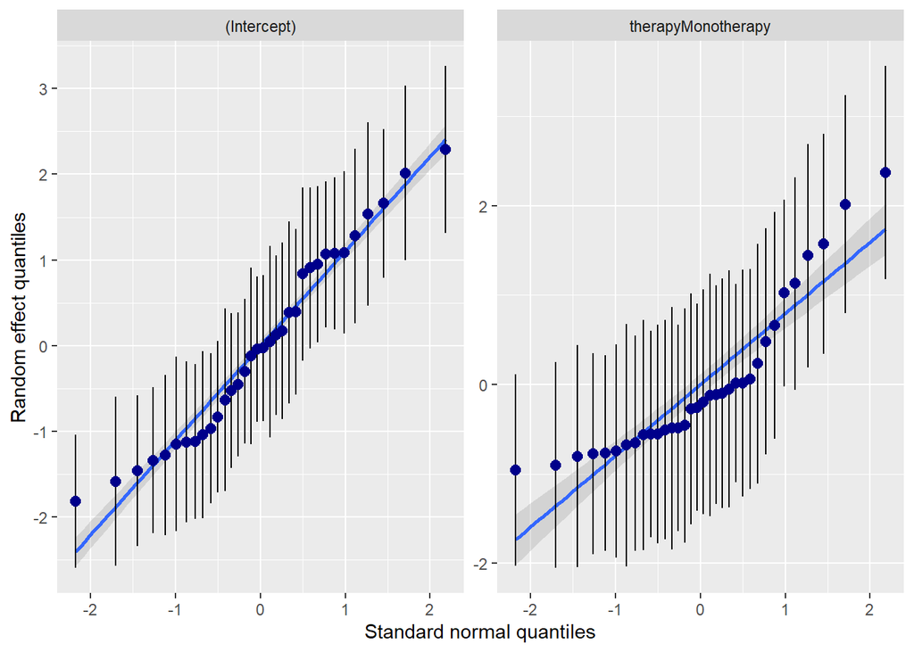

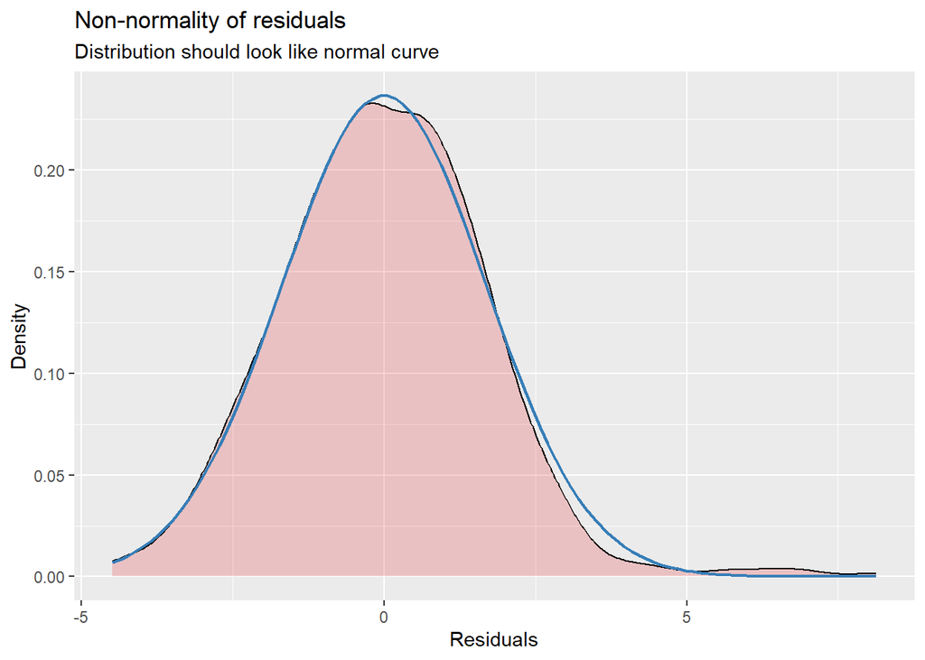

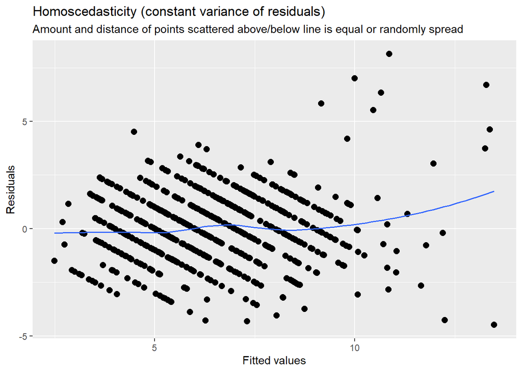

```r
plot_model(final_model, type = 'diag')
```

### Final model

The model can be written as:

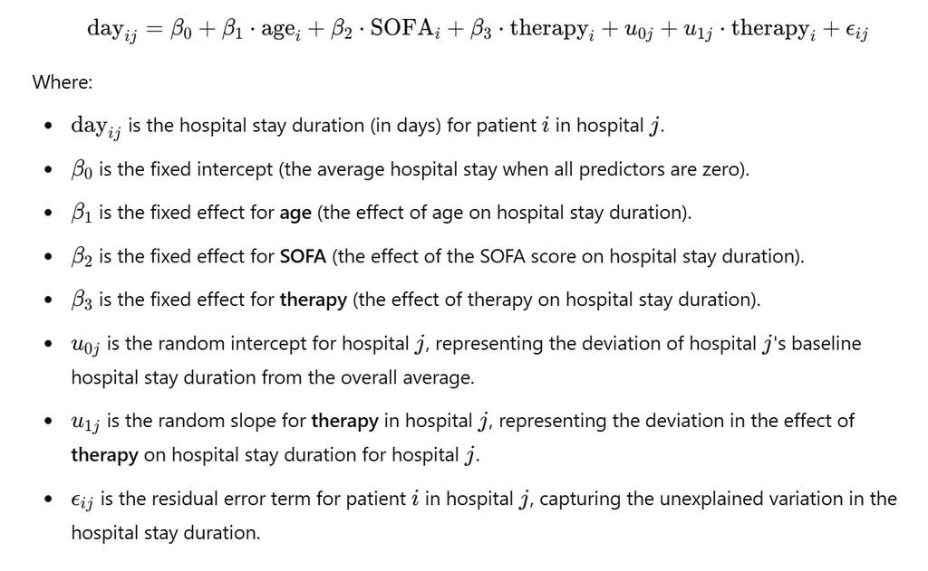

#### Estimate

Lets recall the fixed effect estimates from the model:

```r
tbl_regression(final_model)
```

| **Characteristic** | **Beta** | **95% CI** | **p-value** |
| --- | --- | --- | --- |
| age | 0.00 | -0.01, 0.01 | 0.4 |
| SOFA | 0.24 | 0.20, 0.28 | <0.001 |
| therapy |  |  |  |
| Combination | — | — |  |
| Monotherapy | 1.3 | 0.81, 1.8 | <0.001 |

Abbreviation: CI = Confidence Interval

#### Inference

or obtain the estimates and confidence interval for each predictors using broom.mixed (remove the # when you want to run this code)

```r
#install.packages("broom.mixed")
```

```r
library(broom.mixed)
```

95% CI for the fixed effect estimates

```r
tidy(final_model, conf.int=TRUE)
```

```
# A tibble: 8 × 10
  effect   group     term  estimate std.error statistic    df   p.value conf.low
  <chr>    <chr>     <chr>    <dbl>     <dbl>     <dbl> <dbl>     <dbl>    <dbl>
1 fixed    <NA>      (Int…  3.86      0.346      11.2   148.   2.18e-21  3.18
2 fixed    <NA>      age    0.00428   0.00517     0.827 617.   4.09e- 1 -0.00588
3 fixed    <NA>      SOFA   0.240     0.0182     13.1   608.   6.53e-35  0.204
4 fixed    <NA>      ther…  1.28      0.232       5.51   34.1  3.72e- 6  0.807
5 ran_pars hospital… sd__…  1.22     NA          NA      NA   NA        NA
6 ran_pars hospital… cor_…  0.0634   NA          NA      NA   NA        NA
7 ran_pars hospital… sd__…  1.06     NA          NA      NA   NA        NA
8 ran_pars Residual  sd__…  1.76     NA          NA      NA   NA        NA
# ℹ 1 more variable: conf.high <dbl>
```

extract the random effect for each hospital site

```r
ra.eff.fm <- ranef(final_model, condVar = TRUE)
ra.eff.fm
```

```
$hospital_id
   (Intercept) therapyMonotherapy
1  -0.30065483        -0.77423537
2  -1.46289810         1.57078139
3   2.28887695         2.36824661
4   1.07601931        -0.11836403
5   0.39672934        -0.90321329
6  -1.27901693        -0.65718381
7   0.17369007        -0.67995021
8   0.83500545         1.12811366
9   0.04447641        -0.09877142
10  2.01334616         0.47878273
11  1.53538950        -0.45781241
12  1.06632519         2.01567198
13  0.38790876         1.44006648
```

[output cut: 23 more lines]

95% CI for the random effect

```r
tidy(final_model, effects = 'ran_vals',
     conf.int = TRUE)
```

```
# A tibble: 68 × 8
   effect   group       level term        estimate std.error conf.low conf.high
   <chr>    <chr>       <chr> <chr>          <dbl>     <dbl>    <dbl>     <dbl>
 1 ran_vals hospital_id 1     (Intercept)  -0.301      0.432   -1.15      0.546
 2 ran_vals hospital_id 2     (Intercept)  -1.46       0.448   -2.34     -0.584
 3 ran_vals hospital_id 3     (Intercept)   2.29       0.496    1.32      3.26
 4 ran_vals hospital_id 4     (Intercept)   1.08       0.453    0.188     1.96
 5 ran_vals hospital_id 5     (Intercept)   0.397      0.494   -0.571     1.36
 6 ran_vals hospital_id 6     (Intercept)  -1.28       0.479   -2.22     -0.341
 7 ran_vals hospital_id 7     (Intercept)   0.174      0.526   -0.857     1.20
 8 ran_vals hospital_id 8     (Intercept)   0.835      0.515   -0.175     1.84
 9 ran_vals hospital_id 9     (Intercept)   0.0445     0.569   -1.07      1.16
10 ran_vals hospital_id 10    (Intercept)   2.01       0.520    0.994     3.03
# ℹ 58 more rows
```

### Prediction

lets predict the LOS for each observation

```r
pred_fm <- augment(final_model)
head(pred_fm, 10)
```

```
# A tibble: 10 × 16
     day   age  SOFA therapy    hospital_id .fitted .resid   .hat .cooksd .fixed
   <dbl> <dbl> <dbl> <fct>            <dbl>   <dbl>  <dbl>  <dbl>   <dbl>  <dbl>
 1     8    40     9 Combinati…           1    5.89  2.11  0.0619 2.54e-2   6.19
 2     8    30     9 Monothera…           7    6.92  1.08  0.129  1.60e-2   7.43
 3     4    67     8 Monothera…          28    8.05 -4.05  0.0545 8.08e-2   7.34
 4     6    32     1 Combinati…           4    5.31  0.687 0.0716 3.17e-3   4.24
 5     6    30     6 Monothera…          20    5.51  0.490 0.0942 2.23e-3   6.71
 6     4    39     4 Combinati…          23    3.87  0.133 0.0714 1.19e-4   4.99
 7     7    34    12 Monothera…          27    6.74  0.260 0.103  7.00e-4   8.16
 8     5    54     6 Monothera…           5    6.30 -1.30  0.0589 9.13e-3   6.81
 9     6    56     9 Combinati…          25    6.38 -0.379 0.0761 1.04e-3   6.26
10     6    56     9 Monothera…           7    7.03 -1.03  0.126  1.42e-2   7.54
# ℹ 6 more variables: .mu <dbl>, .offset <dbl>, .sqrtXwt <dbl>, .sqrtrwt <dbl>,
#   .weights <dbl>, .wtres <dbl>
```

### Interpretation and visualization

**Summarize the result in table**

```r
tab_model(final_model)
```

|  | day |  |  |
| --- | --- | --- | --- |
| Predictors | Estimates | CI | p |
| (Intercept) | 3.86 | 3.18 – 4.54 | **<0.001** |
| age | 0.00 | -0.01 – 0.01 | 0.409 |
| SOFA | 0.24 | 0.20 – 0.28 | **<0.001** |
| therapy [Monotherapy] | 1.28 | 0.82 – 1.73 | **<0.001** |
| Random Effects |  |  |  |
| σ<sup>2</sup> | 3.09 |  |  |
| τ<sub>00</sub> <sub>hospital_id</sub> | 1.48 |  |  |
| τ<sub>11</sub> <sub>hospital_id.therapyMonotherapy</sub> | 1.13 |  |  |
| ρ<sub>01</sub> <sub>hospital_id</sub> | 0.06 |  |  |
| ICC | 0.41 |  |  |
| N <sub>hospital_id</sub> | 34 |  |  |
| Observations | 651 |  |  |
| Marginal R<sup>2</sup> / Conditional R<sup>2</sup> | 0.208 / 0.533 |  |  |

**Fixed effect interpretation:**

For each unit increase in SOFA score, the length of hospital stay increase by 0.24 days (95% CI: 0.20, 0.28, p-value <0.001), when adjusted for age, therapy type, random effect of hospital, and random effect of therapy type.

Compared to combined therapy, receiving monotherapy increase the length of hospital stay by 1.28 days (95% CI: 0.83, 1.73, p <0.001) when adjusted for age, SOFA score, random effect of hospital, and random effect of therapy type.

**Random effect interpretation:**

**Visualization**

Plot the random slope vs random intercept

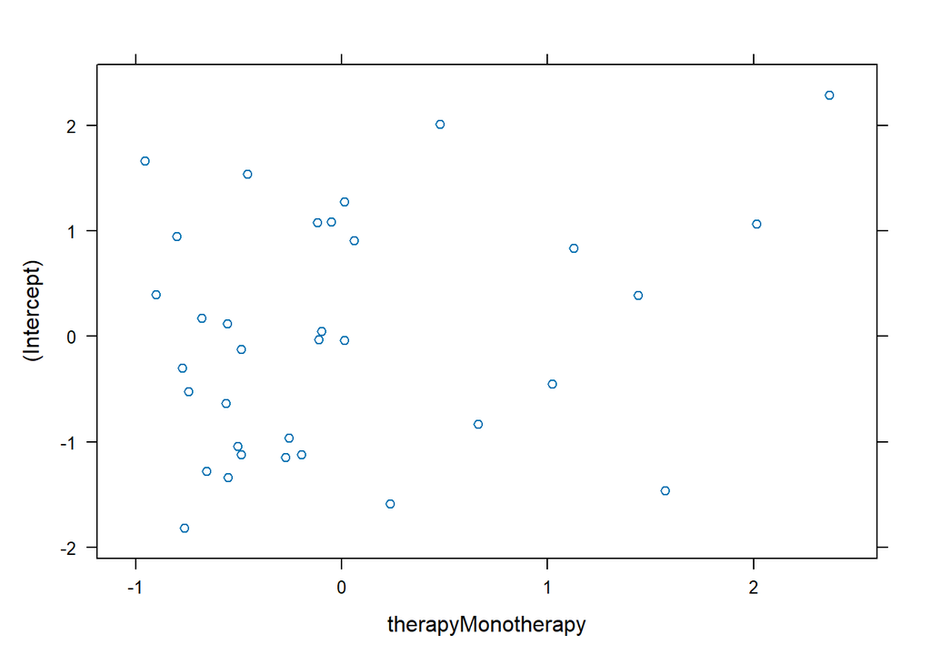

```r
plot(ra.eff.fm)
```

or, you can use ggplot2 and add labels to the dots

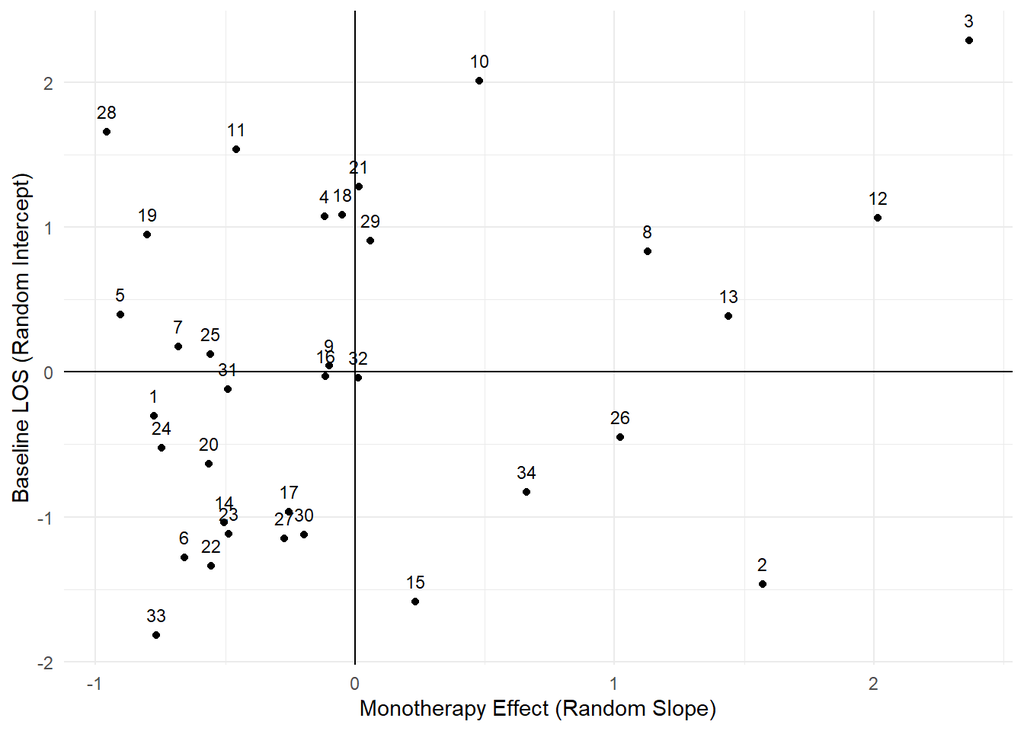

```r
# Extract random effects according to hospital
ran.int <- ranef(final_model)$hospital_id

# Assign hospital id
ran.int_df <- as.data.frame(ran.int)
ran.int_df$hospital_id <- rownames(ran.int_df)

# Rename columns for plotting
colnames(ran.int_df) <- c("Intercept", "therapyMonotherapy", "Hospital_ID")

# Create plot
ggplot(ran.int_df, aes(x = therapyMonotherapy, y = Intercept, label = Hospital_ID)) +
  geom_point() +
  geom_text(aes(label = Hospital_ID), vjust = -1, hjust = 0.5, size = 3) +
  labs(x = "Monotherapy Effect (Random Slope)", y = "Baseline LOS (Random Intercept)") +
  geom_vline(xintercept = 0) +
  geom_hline(yintercept = 0) +
  theme_minimal()
```

**Y-Axis (Intercepts)**: This represents the baseline variation in LOS across hospitals.

**X-Axis (Slopes for Monotherapy Effect)**: This shows how monotherapy affects LOS differently across hospitals.

- **Upper-right quadrant (high intercept, positive slope):** These hospitals start with a high LOS and monotherapy worsens it. Investigate why monotherapy is less effective and consider combination therapy.
- **Upper-left quadrant (high intercept, negative slope):** These hospitals have high baseline LOS, but monotherapy reduces LOS. Preserve monotherapy as an effective strategy.
- **Lower-right quadrant (low intercept, positive slope):** These hospitals have low baseline LOS, but monotherapy increases LOS. Reassess the appropriateness of monotherapy.
- **Lower-left quadrant (low intercept, negative slope):** These hospitals have low baseline LOS and monotherapy further reduces LOS. These hospitals are well-optimized; monitor but no major changes needed.

Plot the fitted value and random slope

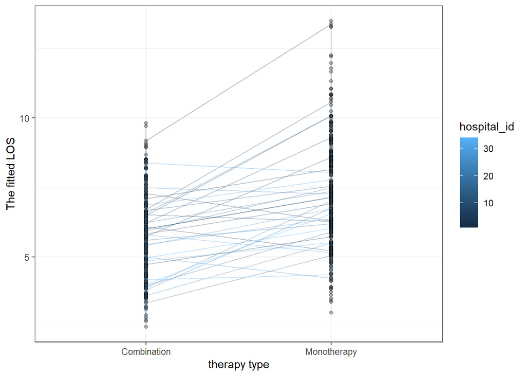

```r
pred_fm %>%
  ggplot(aes(therapy, .fitted, group = hospital_id)) +
  geom_point(alpha = 0.3) +
  geom_line(aes(colour = hospital_id), alpha = 0.3) +
  ylab('The fitted LOS') +
  xlab('therapy type') +
  theme_bw()
```

- The majority of lines **slope** **upward**, suggesting that LOS tends to be longer for patients on monotherapy compared to combination therapy across many hospitals.
- Some hospitals show a **steeper increase** in LOS when switching from combination therapy to monotherapy, while others have a smaller change. A few hospitals even show a slight **decrease** in LOS with monotherapy.
- Lines **differ in direction and steepness**, it supports the finding from the mixed-effects model that the effect of monotherapy on LOS **varies** across hospitals.

Lets plot the random effect of intercept and slope

you can use **sjplot** package to do the plot

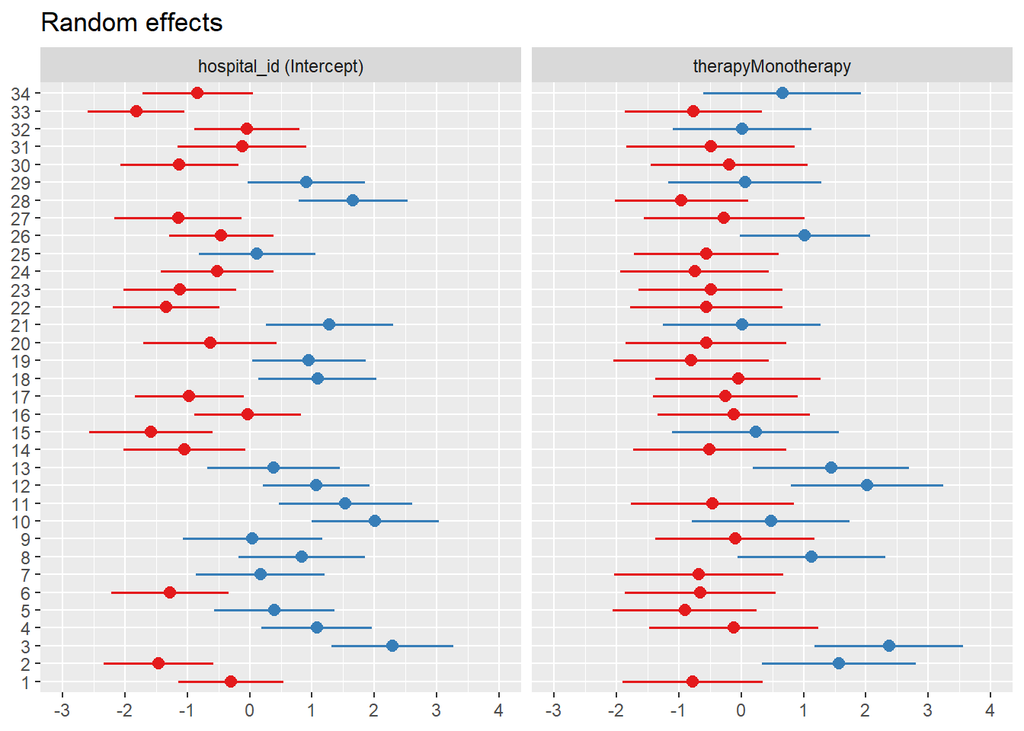

```r
plot_model(final_model, type = "re")
```

or u can use the **doplot** package

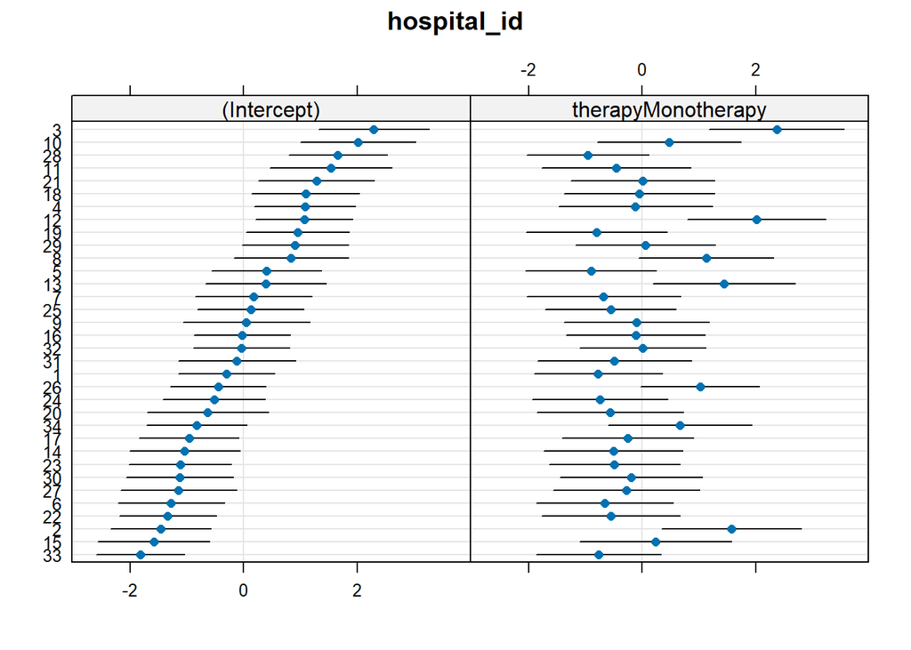

```r
randoms <- ranef(final_model, condVar = TRUE)
dotplot(randoms)
```

**Random intercept:**

- x-axis represent the baseline deviation
- Hospitals with random intercepts above 0 have a **higher baseline LOS** compared to the average hospital.
- Hospitals with negative random intercepts have a **lower baseline LOS** compared to the average.

**Random slope:**

- This shows how the effect of **monotherapy** (compared to the combined therapy) varies across hospitals.
- A positive value means **monotherapy increases LOS** for that hospital.
- A negative value means **monotherapy decreases LOS** for that hospital.

**What do you observe from the analysis?**

**Some hospitals have consistently higher baseline LOS**. Are there delays in diagnostics, resource constraints, or different discharge policies? Identify hospitals with shorter baseline LOS and investigate their strategies. Best practices from these hospitals could be adopted.

**The effect of monotherapy varies by hospital.** In some hospitals, it increases LOS, while in others, it has a negative or little effect. Reassess monotherapy use in hospitals with positive random slopes. Conduct local antibiograms to check for resistance rate and patterns. Expand combination therapy if necessary.

**Hospital-level differences** suggest systemic factors affecting LOS and therapy effectiveness. Instead of applying a uniform policy, allow flexibility based on local conditions.

**Explore Additional Factors Affecting LOS**. Future analyses could include patient severity, comorbidities, and socioeconomic status to determine whether therapy type is the main driver of LOS or if other confounding factors are at play.

## Conclusion

- A standard regression model assumes the same treatment effect applies to all hospitals. However, real-world healthcare settings differ in structure, patient population, and treatment efficiency.
- Multilevel analysis is crucial in this study because it accounts for the hierarchical structure of the data, where patients are nested within hospitals.
- Traditional regression models assume independence of observations, but in reality, patients treated in the same hospital share similar treatment protocols, healthcare resources, and clinical practices.
- Ignoring this within-hospital correlation could lead to biased estimates and incorrect conclusions.
- Understanding hospital-specific variations helps policymakers tailor interventions rather than applying a one-size-fits-all approach.

## Alternative

### GEE model

In GEE, the coefficients still represent the **average change in the dependent variable** for a one-unit change in the predictor, but **with the correlation structure within clusters taken into account**.

The interpretation is still about the **average effect** of the predictors on the outcome, but this effect is estimated while accounting for the **correlation between clustered data points**.

**install package gee**

```r
#install.packages(gee)
```

**load library**

```r
library(gee)
```

**run gee model**

```r
gee_model <- gee(day ~ age + SOFA + therapy,
                 id = hospital_id,
                 data = carba,
                 family = gaussian,
                 corstr = "exchangeable")
```

```
Beginning Cgee S-function, @(#) geeformula.q 4.13 98/01/27
```

```
running glm to get initial regression estimate
```

```
       (Intercept)                age               SOFA therapyMonotherapy
        2.39093300         0.03477741         0.24266658         1.25627578
```

```r
gee_model
```

```
 GEE:  GENERALIZED LINEAR MODELS FOR DEPENDENT DATA
 gee S-function, version 4.13 modified 98/01/27 (1998)

Model:
 Link:                      Identity
 Variance to Mean Relation: Gaussian
 Correlation Structure:     Exchangeable

Call:
gee(formula = day ~ age + SOFA + therapy, id = hospital_id, data = carba,
    family = gaussian, corstr = "exchangeable")

Number of observations :  651

Maximum cluster size   :  2


Coefficients:
       (Intercept)                age               SOFA therapyMonotherapy
         2.3298263          0.0367017          0.2417539          1.2146427

Estimated Scale Parameter:  5.031218
Number of Iterations:  3

Working Correlation[1:4,1:4]
          [,1] [,2] [,3] [,4]
[1,] 1.0000000    0    0    0
[2,] 0.6967707    0    0    0
[3,] 0.6967707    0    0    0
[4,] 1.0000000    0    0    0


Returned Error Value:
[1] 0
```

On average, **each additional year of age** was associated with a **0.037-day increase** in length of stay, adjusting for SOFA score and therapy type.

**Each one-point increase in SOFA score** was associated with an **average increase of 0.242 days** in hospital stay, adjusting for age and therapy type

Patients receiving **monotherapy** had an **average of 1.215 days longer** hospital stay compared to those receiving the combined therapy, adjusting for SOFA score and age.

The working correlation estimate (ρ ≈ 0.697) indicated a moderate degree of within-hospital clustering - justifying the need for GEE.

**Thank you.**

References:

- https://stats.oarc.ucla.edu/other/mult-pkg/introduction-to-linear-mixed-models/
- https://cran.r-project.org/web/packages/lme4/lme4.pdf
- Jiang, J. and Nguyen, T., 2021. **Linear and generalized linear mixed models and their applications**. Springer Nature.
- Meteyard, L., & Davies, R. A. (2020). **Best practice guidance for linear mixed-effects models in psychological science**. Journal of Memory and Language, 112, 104092.
- Silveira LTYD, Ferreira JC, Patino CM. Mixed-effects model: a useful statistical tool for longitudinal and cluster studies. J Bras Pneumol. 2023 May 15;49(2):e20230137. doi: 10.36416/1806-3756/e20230137.
- Twisk, J.W., 2019. **Applied mixed model analysis: a practical guide**. Cambridge University Press